# Exploring relationships for video views

Annie Flippo

This is an exploratory analysis of video views from publish date to various ages for AwesomenessTV channel videos.

## The Data

There are over 4000 videos in the AwesomenessTV channel. This is an analysis to see whether videos’s views from day 0, day 3, day 7 are predictive of their views at day 30 and 60.

In this dataset, there are many videos that are missing views for the first week after they are published. In addition, some videos have not aged to 30 or 60 days. In total, there are 304 videos with views on day 0, 3, 7, 30 and 60 for this analysis.

## Scatter Plots

Scatter plots for 304 for views at day 0, day 3 & day 7 versus views at day 30 & day 60. The horizontal and vertical scales have been set to be the same for all 6 plots for better visual comparisons.

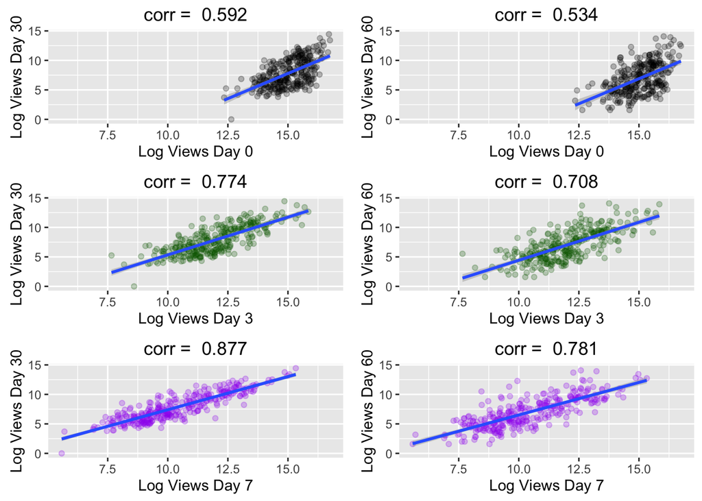

Note that as the predictive period is shortened the tigher the scatter plots are which seems to makes sense. That means day 7 view is better at predicting day 30’s views than day 0’s view. Moreover, all scatterplots here show a positive trend for future video views.

## Normality in Residuals from Linear Regressions

In this analysis, normality of residuals is assumed. It’s important to test whether this assumption holds. Since there are six regression combinations, it’s not necessary to plot all 6 x 4 residual graphs. Here, I evaluate this by examining residual plots that for LogDay30 ~ Fn(LogDay7) as an illustration that normality assumption seems reasonable in this case.

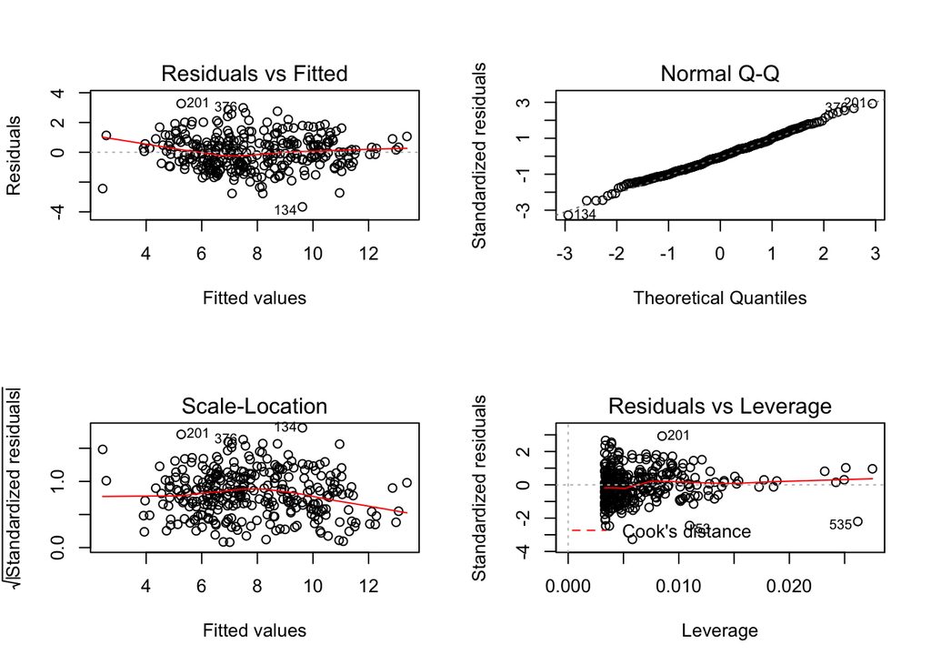

## Histograms - Normality in Residuals

Plotting the frequency of the residuals gives a visual sense of normality in the residuals. This implies that a simple linear regression of the differences between actual day 30/60 views and predicted day 30/60 views falls within a normal distribution. We should not expect too many poorly predicted views and the errors in prediction are centered around zero.

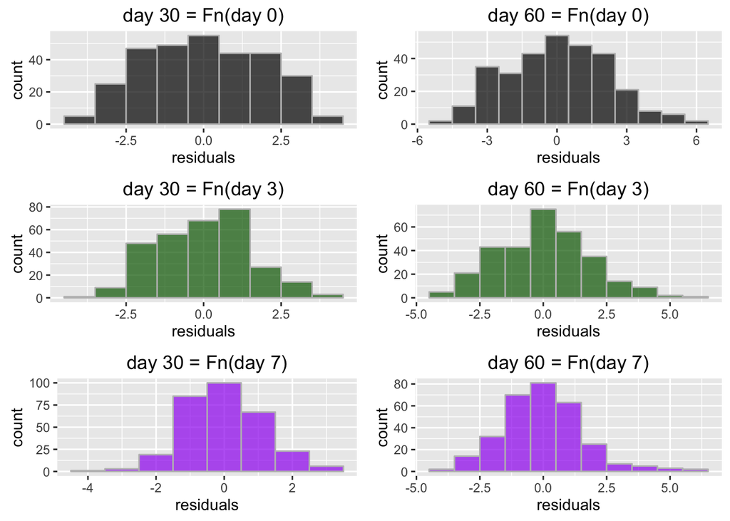

## Summary

In the 2008 Szabo and Huberman’s article<sup>1</sup>, *Predicting the popularity of online content*, where they’ve found correlation for views between early and later times, the awesomenessTV’s videos also exhibit the same behavior. This is good news as we can predict future views based on earlier views for our videos.

There are other attributes to be explore in the future such as YouTube Category, Content Category, Topics and more that might impact views.

### References

1. Szabo, G and Huberman, B. (Nov 2008), Predicting the popularity of online content, *Cornell University Library, arXiv:0811.0405v1*, Retrieved from http://arxiv.org/pdf/0811.0405.pdf.